# Antfin

Cynthia Li, CFA

12/17/2017

## 笔试题：

> 1. 描述一个你曾经完成或参与的数据分析的项目 A）数据集的大小，包含多少变量/字段？你曾经用过的最大数据是多少？数据的采样是如何进行 的？如果是你进行采样，用了什么语言/算法/软件？

> 回答：几个G的数据量，包含30多个变量，用过的最大数据是几十G，数据采样的方法是stratified sampling，我当时用的是R里分层抽样的方法

> B）在数据处理中，你需要考虑哪些因素，是否需要做数据清洗？是否数据采样有取样偏差 （sampling Bias）？

> 回答：在数据处理中会遇到很多不同的问题，比如前后数据的inconsistency，单位错误，缺失，无效，错误等，以及不同数据源整合时遇到的重复，不匹配等问题，所以需要数据清洗，数据采样会造成偏差，比如不平衡的categorical data，简单总结如下：
- 单数据源问题
  - 数据 schema 设计问题，比如缺失 integrity constraint
  - instance问题，比如输入错误，拼写错误，redundancy/duplicates，contradictory值等
- 多数据源问题
  - 数据 schema 设计问题，比如naming conflict，structural conflict
  - instance问题，比如inconsistent aggregating, inconsistent timing等
> 3. 你采用了什么样的分析/建模方法？是否这些方法符合业界标准？是否对你的数据最优？

> 回答：我一般会先观察数据类型，取值范围，密度分布等，这样对要解决的问题有个快速理解，然后从最简单的线性模型开始，比如逻辑回归，当feature很多时，我会再用上ridge或者lasso这种regulization technique，然后会尝试非线性模型，比如random forest和GBM，random forest的优点是可以做feature importance analysis和feature selection，GBM模型中我用的最多的是xgboost，因为它不仅有树模型的优点，同时在不compromise accuracy的前提下，有较快的运算速度。这些方法同样也是纽约业界的标准，从最简单的模型开始，不盲目追求复杂模型，首先探索模型对业务问题的可解释性，理解所要解决问题的相关因素，然后逐步深入和优化。随着对问题的不断理解和加深，可以做更好的feature engineering，而且为了最大化地 利用有限的数据，还可以使用bootstrap的方法。
> 4. 如何实现以上的方法？

> 回答：ridge和lasso在R中都有相应library和参数可以使用和设置，random forest和GBM模型有很多不同算法可以使用，random forest差别不大，GBM业界比较公认性能较好的是xgboost，feature engineering有很多方法，简单讲我总结了四个大类：
- Embedded Method: 比如 random forest的feature importance rank可以参考
- Wrapper Method: 还可以尝试forward和backward selection，比如recursive feature elimination
- Feature Filter: 还可以通过correlation coefficient做feature filter
- 重构feature: 比如通过LDA或者PCA的方法
> 2. 你常用哪些方法清洗/分析数据?

> 回答：首先metadata可以让我们对数据的质量情况有个大致了解，然后第一步是data analysis，比如对于无效数据，拼写错误，缺失值，重复值，和变化数据的处理，同时观察数据分布等stats取值。这一步中提到的对**缺失值** 的处理，有一整套系统的方法，我发表的一篇博客文章专门有对这个问题的总结，链接：https://rpubs.com/flyunicorn/179395。第二部是对 data transformation de的的定义，如在ETL中遇到的data mapping rule，特别是有 user-defined functions (UDFs) 的情况下。第三步是解决数据conflict问题，比如百分数表达方式，单位划一等，这一步中还有一点非常重要的是数据的标准化
> 3. 数据分析与建模测试

### Environment setup

```r
library(knitr)
library(readr)
library(plyr)
library(dplyr)
library(magrittr)
library(ggplot2)
library(caret)
library(tidyr)
library(car)
library(glmnet)
library(broom)
library(rpart)
library(leaps)
library(randomForest)
library(gbm)
library(xgboost)
library(Ckmeans.1d.dp)
library(DiagrammeR)
library(devtools)
install_github("easyGgplot2", "kassambara")
library(easyGgplot2)
library(purrr)
library(tibble)
library(ROSE)
library(ROCR)
options(digits = 7)
setwd("~/Downloads")
```

### Load Data & Data Checking & Transformation

```r
ads_train <- read_csv('~/Downloads/ads_train.csv') %>% mutate(type='train')
ads_test <- read_csv('~/Downloads/ads_test.csv') %>% mutate(type='test',y_buy=NA)

str(ads_train)
```

```
## Classes 'tbl_df', 'tbl' and 'data.frame':    38209 obs. of  15 variables:
##  $ isbuyer            : int  1 1 1 1 1 1 1 1 1 1 ...
##  $ buy_freq           : int  2 2 3 4 2 2 2 3 2 2 ...
##  $ visit_freq         : int  11 75 49 45 2 5 20 6 2 28 ...
##  $ buy_interval       : num  36.0417 6.0417 45.125 16.9722 0.0417 ...
##  $ sv_interval        : num  17.4667 1.8902 2.5842 2.2983 0.0417 ...
##  $ expected_time_buy  : num  2.19 -39.08 -58.93 -26.27 -19.11 ...
##  $ expected_time_visit: num  8.67 0.685 1.809 -2.628 -19.112 ...
##  $ last_buy           : int  7 1 0 4 19 67 4 41 0 2 ...
##  $ last_visit         : int  7 1 0 4 19 67 4 41 0 2 ...
##  $ multiple_buy       : int  1 1 1 1 1 1 1 1 1 1 ...
##  $ multiple_visit     : int  1 1 1 1 1 1 1 1 1 1 ...
##  $ uniq_urls          : int  189 65 158 46 32 50 19 150 18 55 ...
##  $ num_checkins       : int  1008 405 1314 289 580 188 142 922 65 377 ...
##  $ y_buy              : int  1 0 1 1 0 0 0 0 0 1 ...
##  $ type               : chr  "train" "train" "train" "train" ...
```

```r
str(ads_train)
```

```
## Classes 'tbl_df', 'tbl' and 'data.frame':    38209 obs. of  15 variables:
##  $ isbuyer            : int  1 1 1 1 1 1 1 1 1 1 ...
##  $ buy_freq           : int  2 2 3 4 2 2 2 3 2 2 ...
##  $ visit_freq         : int  11 75 49 45 2 5 20 6 2 28 ...
##  $ buy_interval       : num  36.0417 6.0417 45.125 16.9722 0.0417 ...
##  $ sv_interval        : num  17.4667 1.8902 2.5842 2.2983 0.0417 ...
##  $ expected_time_buy  : num  2.19 -39.08 -58.93 -26.27 -19.11 ...
##  $ expected_time_visit: num  8.67 0.685 1.809 -2.628 -19.112 ...
##  $ last_buy           : int  7 1 0 4 19 67 4 41 0 2 ...
##  $ last_visit         : int  7 1 0 4 19 67 4 41 0 2 ...
##  $ multiple_buy       : int  1 1 1 1 1 1 1 1 1 1 ...
##  $ multiple_visit     : int  1 1 1 1 1 1 1 1 1 1 ...
##  $ uniq_urls          : int  189 65 158 46 32 50 19 150 18 55 ...
##  $ num_checkins       : int  1008 405 1314 289 580 188 142 922 65 377 ...
##  $ y_buy              : int  1 0 1 1 0 0 0 0 0 1 ...
##  $ type               : chr  "train" "train" "train" "train" ...
```

```r
summary(ads_train)
```

```
##     isbuyer          buy_freq       visit_freq      buy_interval
##  Min.   :0.0000   Min.   : 1.00   Min.   : 0.000   Min.   :  0.0000
##  1st Qu.:0.0000   1st Qu.: 1.00   1st Qu.: 1.000   1st Qu.:  0.0000
##  Median :0.0000   Median : 1.00   Median : 1.000   Median :  0.0000
##  Mean   :0.0424   Mean   : 1.24   Mean   : 1.868   Mean   :  0.1974
##  3rd Qu.:0.0000   3rd Qu.: 1.00   3rd Qu.: 2.000   3rd Qu.:  0.0000
##  Max.   :1.0000   Max.   :15.00   Max.   :84.000   Max.   :174.6250
##                   NA's   :36589
##   sv_interval      expected_time_buy   expected_time_visit
##  Min.   :  0.000   Min.   :-181.9238   Min.   :-187.62
##  1st Qu.:  0.000   1st Qu.:   0.0000   1st Qu.:   0.00
##  Median :  0.000   Median :   0.0000   Median :   0.00
##  Mean   :  5.862   Mean   :  -0.1744   Mean   : -10.14
##  3rd Qu.:  0.125   3rd Qu.:   0.0000   3rd Qu.:   0.00
##  Max.   :184.917   Max.   :  84.2857   Max.   :  91.40
##
##     last_buy        last_visit      multiple_buy      multiple_visit
##  Min.   :  0.00   Min.   :  0.00   Min.   :0.000000   Min.   :0.0000
##  1st Qu.: 18.00   1st Qu.: 18.00   1st Qu.:0.000000   1st Qu.:0.0000
##  Median : 50.00   Median : 50.00   Median :0.000000   Median :0.0000
##  Mean   : 64.66   Mean   : 64.66   Mean   :0.005967   Mean   :0.2775
##  3rd Qu.:105.00   3rd Qu.:105.00   3rd Qu.:0.000000   3rd Qu.:1.0000
##  Max.   :188.00   Max.   :188.00   Max.   :1.000000   Max.   :1.0000
##
##    uniq_urls       num_checkins         y_buy              type
##  Min.   : -1.00   Min.   :    1.0   Min.   :0.000000   Length:38209
##  1st Qu.: 30.00   1st Qu.:  127.0   1st Qu.:0.000000   Class :character
##  Median : 75.00   Median :  319.0   Median :0.000000   Mode  :character
##  Mean   : 86.59   Mean   :  723.8   Mean   :0.004502
##  3rd Qu.:155.00   3rd Qu.:  803.0   3rd Qu.:0.000000
##  Max.   :206.00   Max.   :37091.0   Max.   :1.000000
##
```

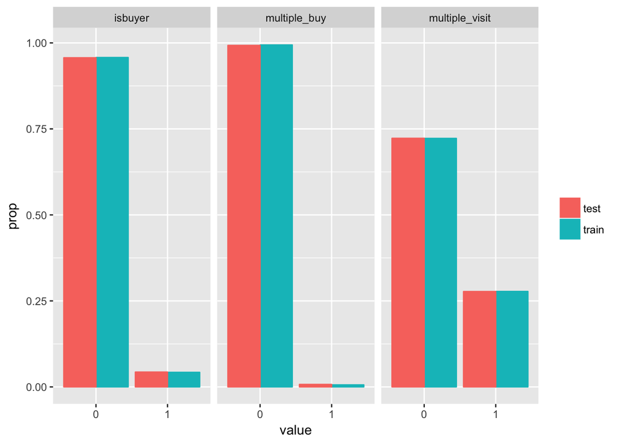

```r
factorVars <- c("isbuyer","multiple_buy","multiple_visit","y_buy","type")
numericVars <- setdiff(names(ads_train),factorVars)
ads_all <- rbind(ads_train,ads_test) %>% map_at(factorVars,as.factor) %>% as_tibble
ads_all %>% select(c(isbuyer,multiple_buy,multiple_visit,y_buy,type)) %>% select(-y_buy) %>%
  gather('variable','value',-type)  %>%
  ggplot(aes(x=value,group=factor(type))) +
  geom_bar(aes(y = ..prop..,color=factor(type),fill=factor(type)),
           stat='count',position = 'dodge') +
  facet_wrap(~variable, scales='free_x') +
  theme(legend.title = element_blank())
```

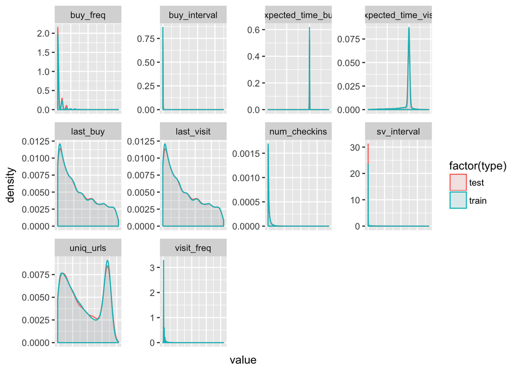

```r
ads_all %>% select(c(buy_freq,visit_freq,buy_interval,sv_interval,expected_time_buy,expected_time_visit,last_buy,last_visit,uniq_urls,num_checkins,type)) %>%
  gather('variable','value',-type) %>%
  ggplot(aes(x=value,group=type, color=factor(type),fill=factor(type))) +
  geom_density(alpha=0.1) +
  facet_wrap(~variable, scales=c('free')) +
  theme(axis.text.x=element_blank(),
        axis.ticks.x=element_blank())
```

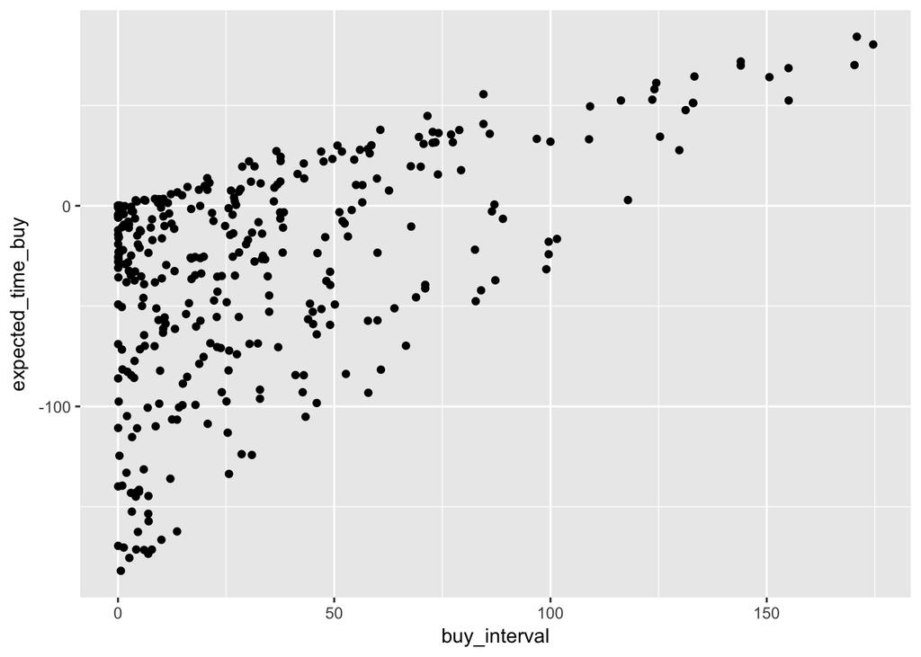

```r
ads_all %>% ggplot(aes(x=buy_interval,y=expected_time_buy)) + geom_point()
```

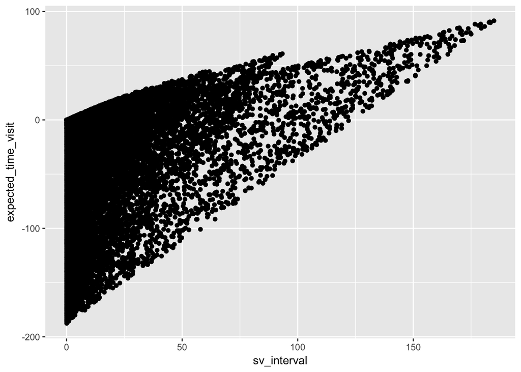

```r
ads_all %>% ggplot(aes(x=sv_interval,y=expected_time_visit)) + geom_point()
```

### Exploratory data analysis on categorical variables

```r
table(ads_train$isbuyer,ads_train$y_buy)
```

```
##
##         0     1
##   0 36480   109
##   1  1557    63
```

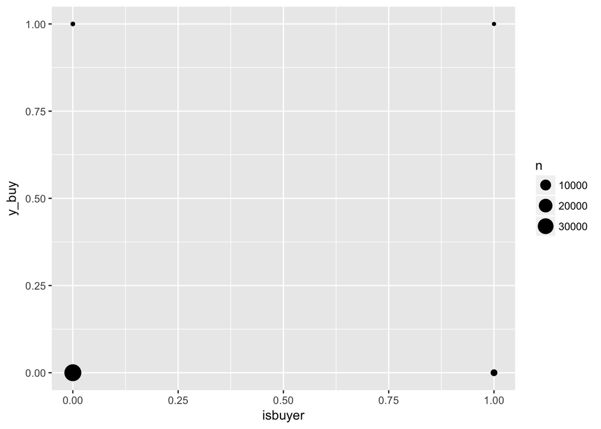

```r
ggplot(data = ads_train) + geom_count(mapping = aes(x = isbuyer, y = y_buy))
```

```r
table(ads_train$multiple_buy,ads_train$y_buy)
```

```
##
##         0     1
##   0 37834   147
##   1   203    25
```

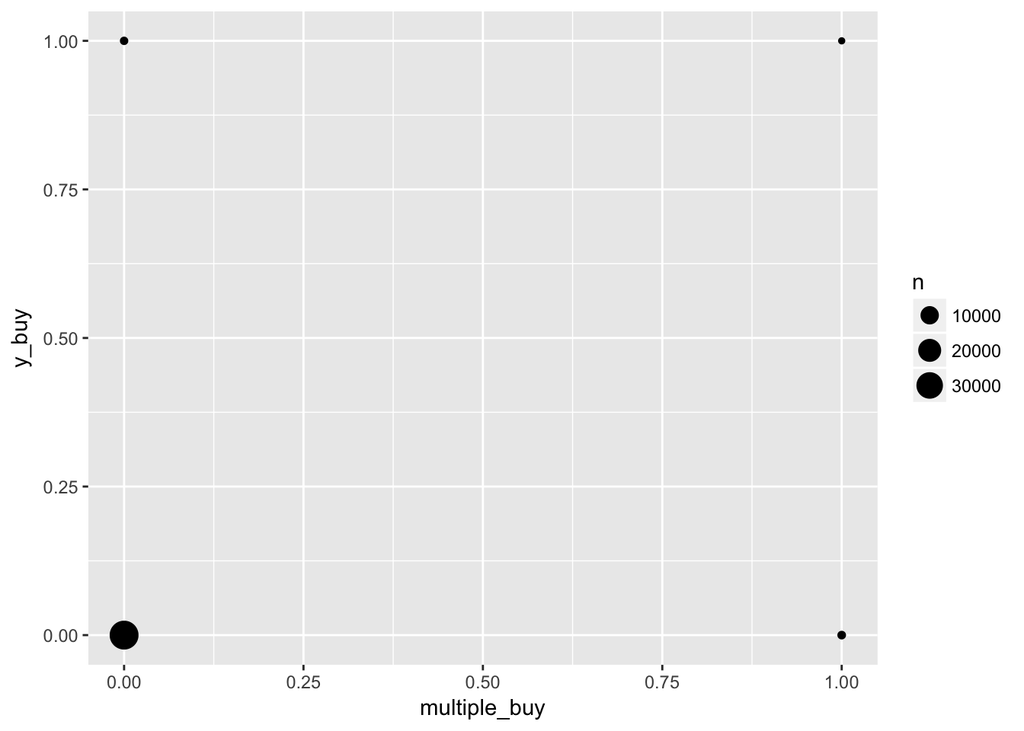

```r
ggplot(data = ads_train) + geom_count(mapping = aes(x = multiple_buy, y = y_buy))
```

```r
table(ads_train$multiple_visit,ads_train$y_buy)
```

```
##
##         0     1
##   0 27556    49
##   1 10481   123
```

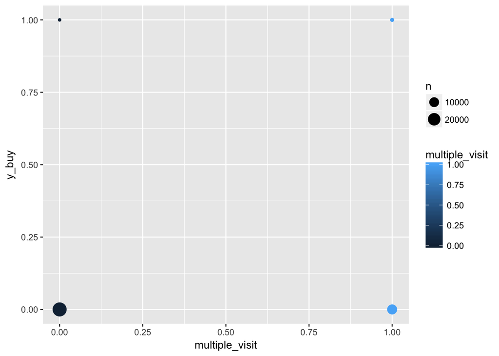

```r
ggplot(data = ads_train) + geom_count(mapping = aes(x = multiple_visit, y = y_buy, col=multiple_visit))
```

```r
table(ads_train$multiple_buy,ads_train$isbuyer)
```

```
##
##         0     1
##   0 36589  1392
##   1     0   228
```

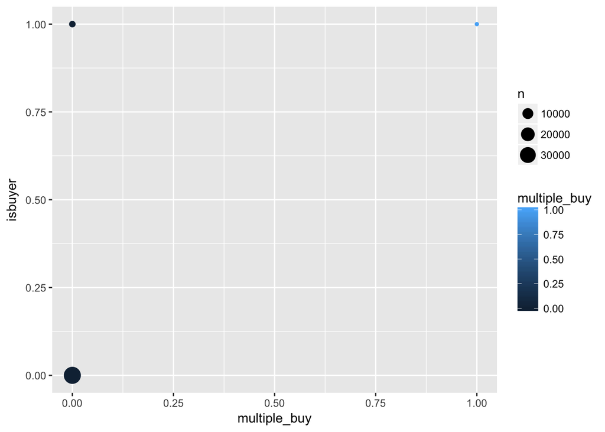

```r
ggplot(data = ads_train) + geom_count(mapping = aes(x = multiple_buy, y = isbuyer, col=multiple_buy))
```

### Exploratory data analysis on numeric variables

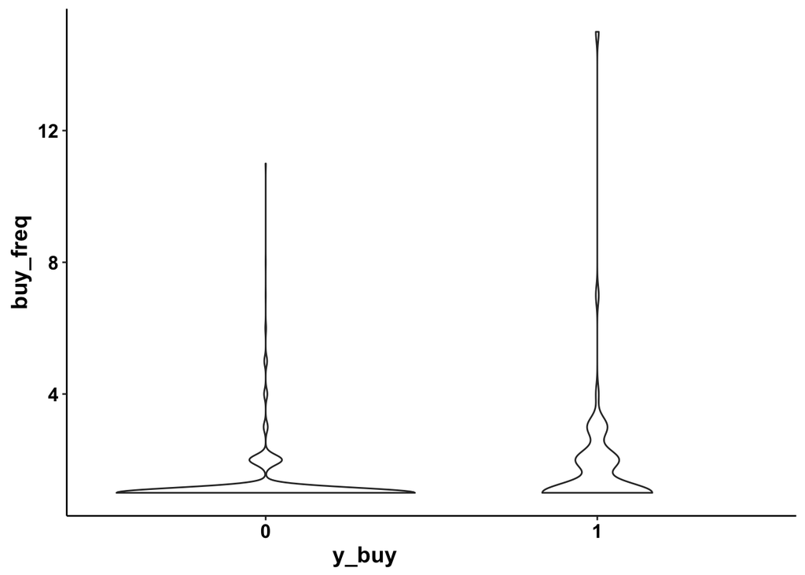

```r
ggplot2.violinplot(data=ads_train, xName='y_buy',yName='buy_freq', backgroundColor="white", fill='#FFAAD4',
                removePanelGrid=TRUE,removePanelBorder=TRUE, axisLine=c(0.5, "solid", "black"))
```

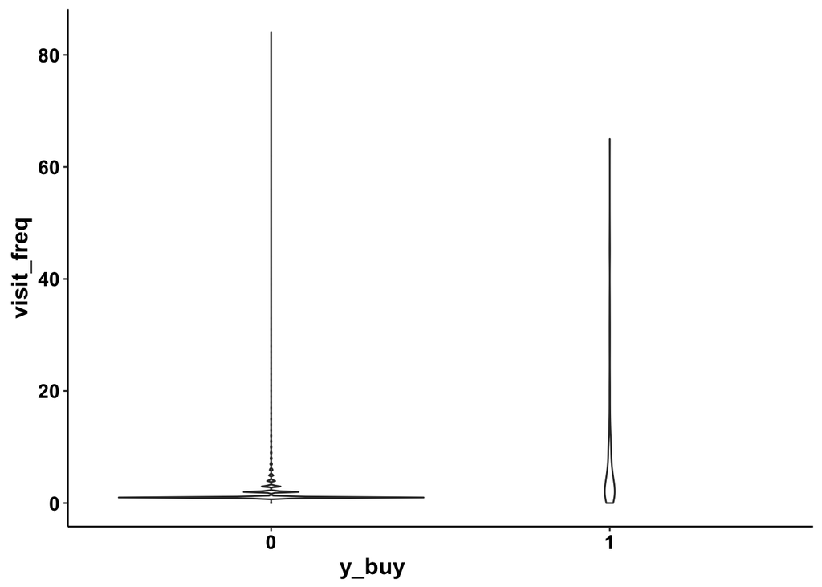

```r
ggplot2.violinplot(data=ads_train, xName='y_buy',yName='visit_freq', backgroundColor="white", fill='#FFAAD4',
                removePanelGrid=TRUE,removePanelBorder=TRUE, axisLine=c(0.5, "solid", "black"))
```

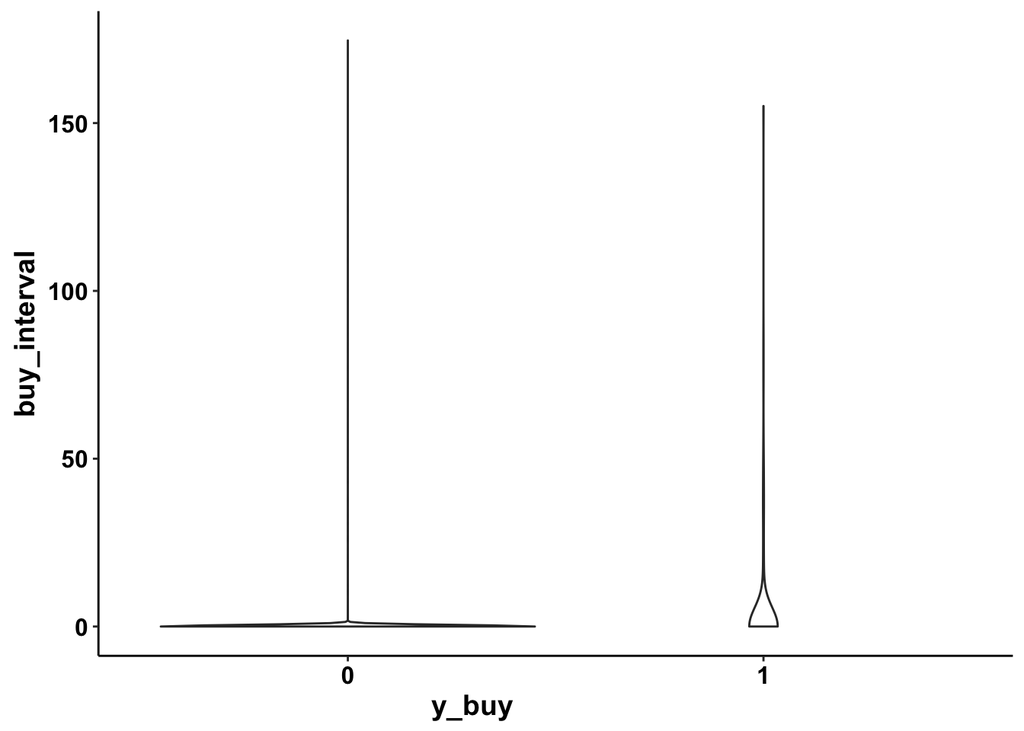

```r
ggplot2.violinplot(data=ads_train, xName='y_buy',yName='buy_interval', backgroundColor="white", fill='#FFAAD4',
                removePanelGrid=TRUE,removePanelBorder=TRUE, axisLine=c(0.5, "solid", "black"))
```

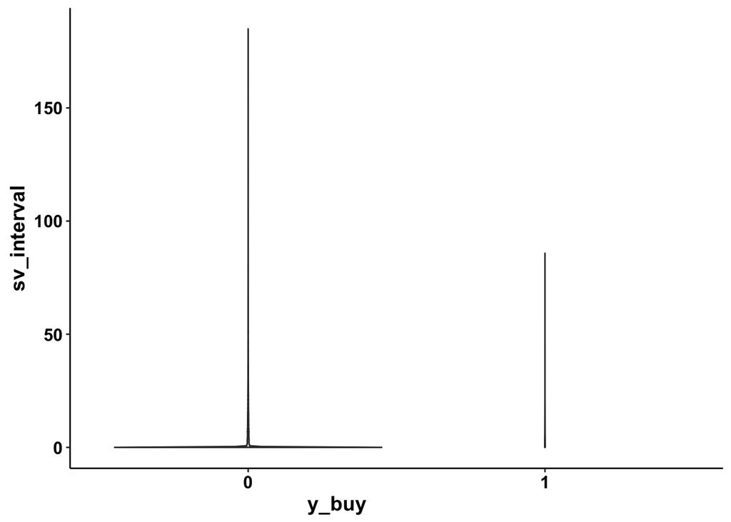

```r
ggplot2.violinplot(data=ads_train, xName='y_buy',yName='sv_interval', backgroundColor="white", fill='#FFAAD4',
                removePanelGrid=TRUE,removePanelBorder=TRUE, axisLine=c(0.5, "solid", "black"))
```

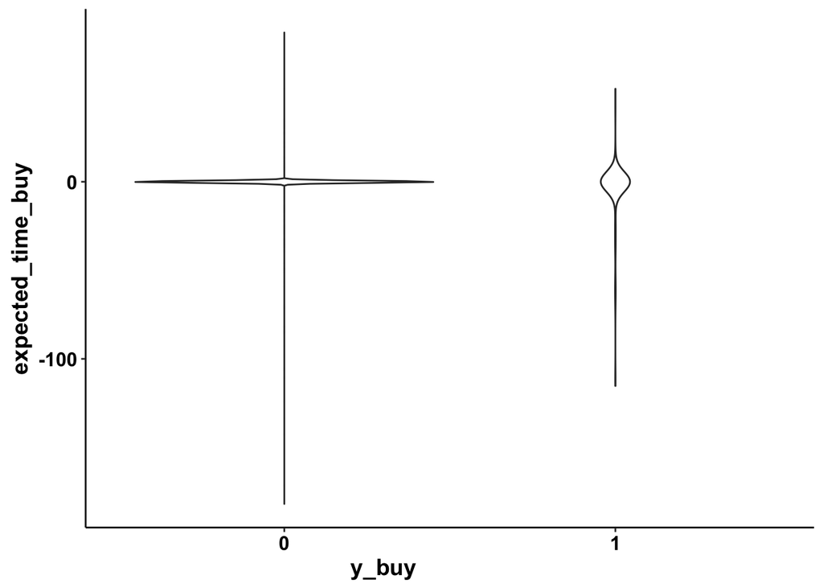

```r
ggplot2.violinplot(data=ads_train, xName='y_buy',yName='expected_time_buy', backgroundColor="white", fill='#FFAAD4',
                removePanelGrid=TRUE,removePanelBorder=TRUE, axisLine=c(0.5, "solid", "black"))
```

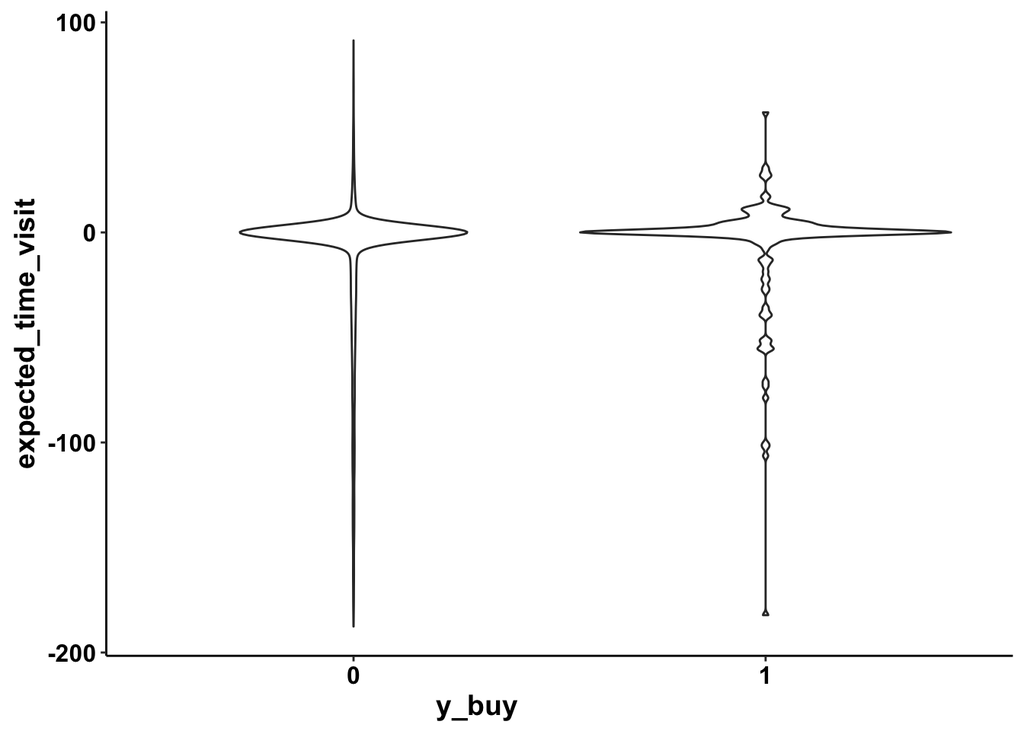

```r
ggplot2.violinplot(data=ads_train, xName='y_buy',yName='expected_time_visit', backgroundColor="white", fill='#FFAAD4',
                removePanelGrid=TRUE,removePanelBorder=TRUE, axisLine=c(0.5, "solid", "black"))
```

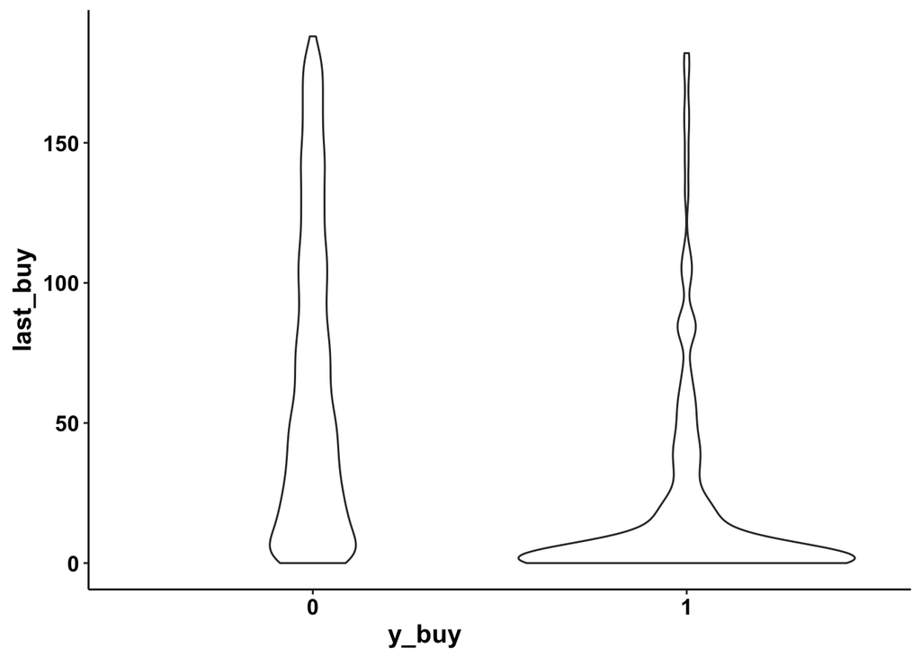

```r
ggplot2.violinplot(data=ads_train, xName='y_buy',yName='last_buy', backgroundColor="white", fill='#FFAAD4',
                removePanelGrid=TRUE,removePanelBorder=TRUE, axisLine=c(0.5, "solid", "black"))
```

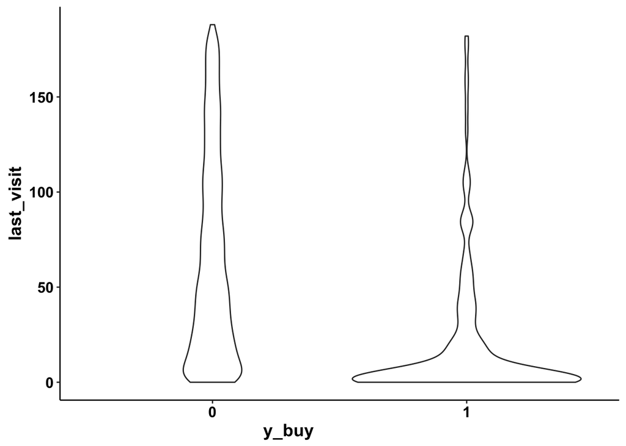

```r
ggplot2.violinplot(data=ads_train, xName='y_buy',yName='last_visit', backgroundColor="white", fill='#FFAAD4',
                removePanelGrid=TRUE,removePanelBorder=TRUE, axisLine=c(0.5, "solid", "black"))
```

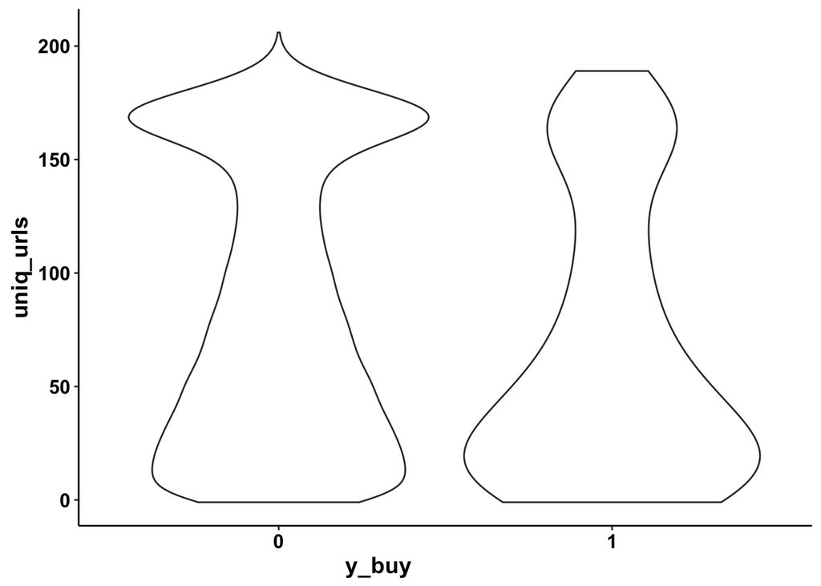

```r
ggplot2.violinplot(data=ads_train, xName='y_buy',yName='uniq_urls', backgroundColor="white", fill='#FFAAD4',
                removePanelGrid=TRUE,removePanelBorder=TRUE, axisLine=c(0.5, "solid", "black"))
```

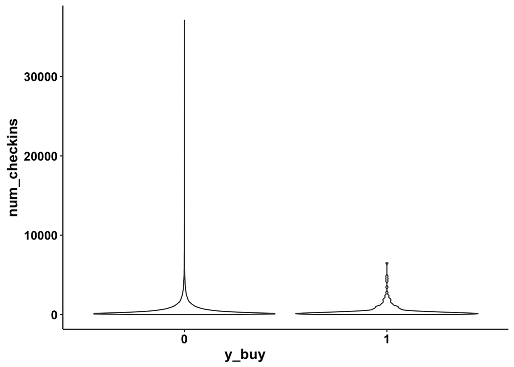

```r
ggplot2.violinplot(data=ads_train, xName='y_buy',yName='num_checkins', backgroundColor="white", fill='#FFAAD4',
                removePanelGrid=TRUE,removePanelBorder=TRUE, axisLine=c(0.5, "solid", "black"))
```

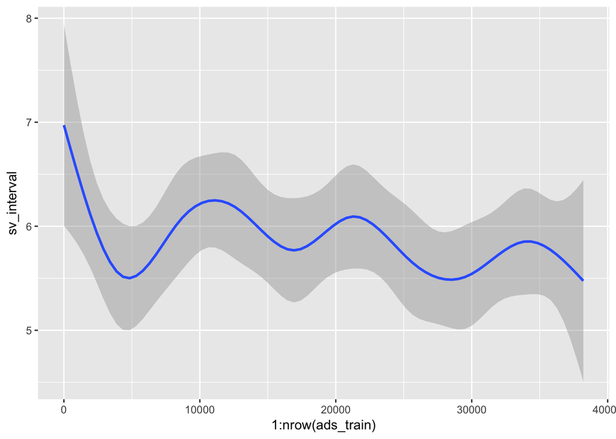

```r
ggplot(ads_train,aes(1:nrow(ads_train),sv_interval,col=ads_train$y_buy))+geom_smooth()
```

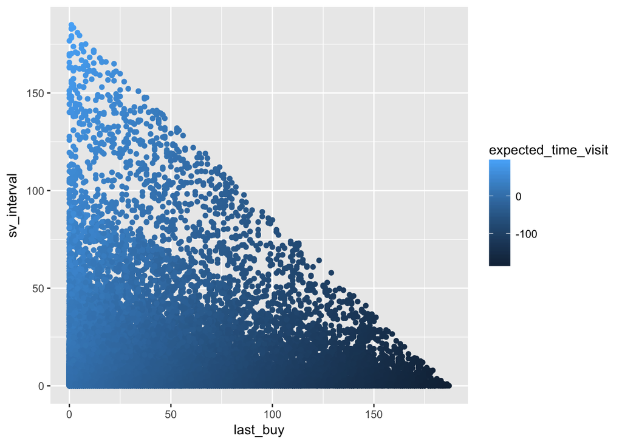

```r
ads_all %>% filter(sv_interval>0) %>% ggplot(aes(x=last_buy ,y=sv_interval)) + geom_point(aes(color=expected_time_visit))
```

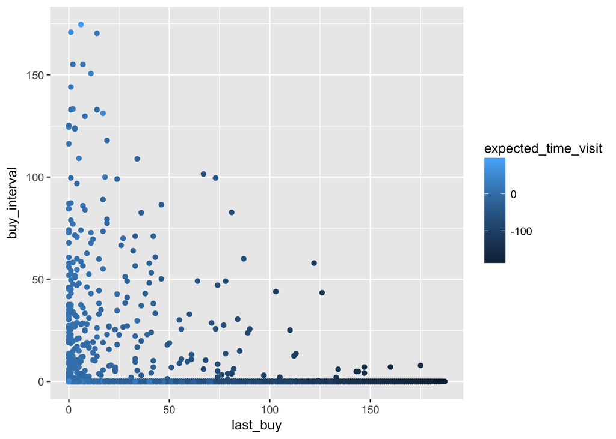

```r
ads_all %>% filter(sv_interval>0) %>% ggplot(aes(x=last_buy ,y=buy_interval)) + geom_point(aes(color=expected_time_visit))
```

#### Findings from EDA

- `last_buy` and `last_visit` are identical features
- NAs in `buy_freq` can be coded as 0
- multiple_buy: buy more than once
- multiple_visit: visit more than once
- expected_time_buy: a hybrid variable that’s derived from `last_buy` and `buy_interval` (**The `last_buy`/`last_visit` variable isn’t coded correctly in the original datasets to figure out the exact formula**)
- expected_time_visit: a hybrid variable that’s derived from `last_visit` and `sv_interval`
- One potential data anomaly is that expected time is negative
- By combining and checking train and test sets together, we make sure feature distribution are comparable which is an often-neglected step in modeling
- An important point in this modeling is the unbalanced classification of outcome variable. Four methods can be used to deal with this issue: up/over sampling, ROSE and SMOTE. Here we choose ROSE.

### Explore features’ impact on outcome variable and feature engineering

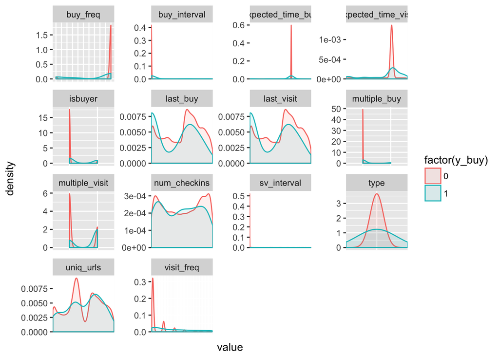

```r
ads_train %>% gather('variable','value',-y_buy) %>%
  ggplot(aes(x=value,group=y_buy, color=factor(y_buy),fill=factor(y_buy))) +
  geom_density(alpha=0.1) +
  facet_wrap(~variable, scales=c('free')) +
  theme(axis.text.x=element_blank(),
        axis.ticks.x=element_blank())
```

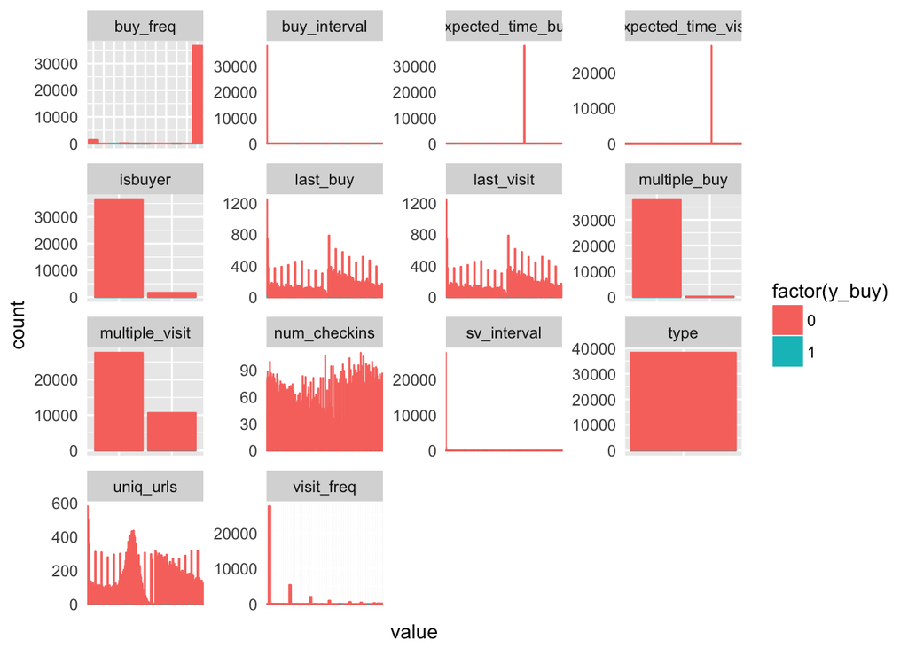

```r
ads_train %>% gather('variable','value',-y_buy) %>%
  ggplot(aes(x=value,group=y_buy, color=factor(y_buy),fill=factor(y_buy))) +
  geom_bar() +facet_wrap(~variable, scales=c('free')) +
  theme(axis.ticks = element_blank(), axis.text.x = element_blank())
```

```r
# anomolies: because last_buy and last_visit are identical features, we delete one of them.
ads_all$last_visit <- NULL
# because of abnormal distribution of num_checkins, we log it
ads_all_trans <- ads_all %>% mutate(num_checkins_log=log(num_checkins+1))
ads_all_trans$num_checkins <- NULL
ads_all_trans$type <- NULL
```

### Data split

```r
set.seed(1)
ads_train <- ads_all_trans[!is.na(ads_all_trans$y_buy),]
ads_test <- ads_all_trans[is.na(ads_all_trans$y_buy),]
ads_train$buy_freq[is.na(ads_train$buy_freq)] <- 0
ads_test$buy_freq[is.na(ads_test$buy_freq)] <- 0
in_train <- createDataPartition(ads_train$y_buy, p = 0.8, list = FALSE)
training <- ads_train[in_train,]
testing <- ads_train[-in_train,]
truth <- testing$y_buy
testing$y_buy <- NULL
```

### Model building & Model evaluation - `glm`

```r
ctrl <- trainControl(method = "repeatedcv",
                     number = 10,
                     repeats = 10,
                     verboseIter = FALSE,
                     sampling = "rose")
set.seed(1)
model_glm_rose <- caret::train(y_buy ~ .,
                              data = training,
                              method = "glm",
                              family="binomial",
                              preProcess = c("scale", "center"),
                              trControl = ctrl)
final_rose <- data.frame(actual = truth, predict(model_glm_rose, newdata = testing, type = "prob"))
final_rose$predict <- ifelse(final_rose$X0 > 0.5, "0", "1")
confusionMatrix(final_rose$predict, truth)
```

```
## Confusion Matrix and Statistics
##
##           Reference
## Prediction    0    1
##          0 6312    5
##          1 1295   29
##
##                Accuracy : 0.8299
##                  95% CI : (0.8212, 0.8382)
##     No Information Rate : 0.9956
##     P-Value [Acc > NIR] : 1
##
##                   Kappa : 0.0343
##  Mcnemar's Test P-Value : <2e-16
##
##             Sensitivity : 0.8298
##             Specificity : 0.8529
##          Pos Pred Value : 0.9992
##          Neg Pred Value : 0.0219
##              Prevalence : 0.9956
##          Detection Rate : 0.8261
##    Detection Prevalence : 0.8267
##       Balanced Accuracy : 0.8414
##
##        'Positive' Class : 0
##
```

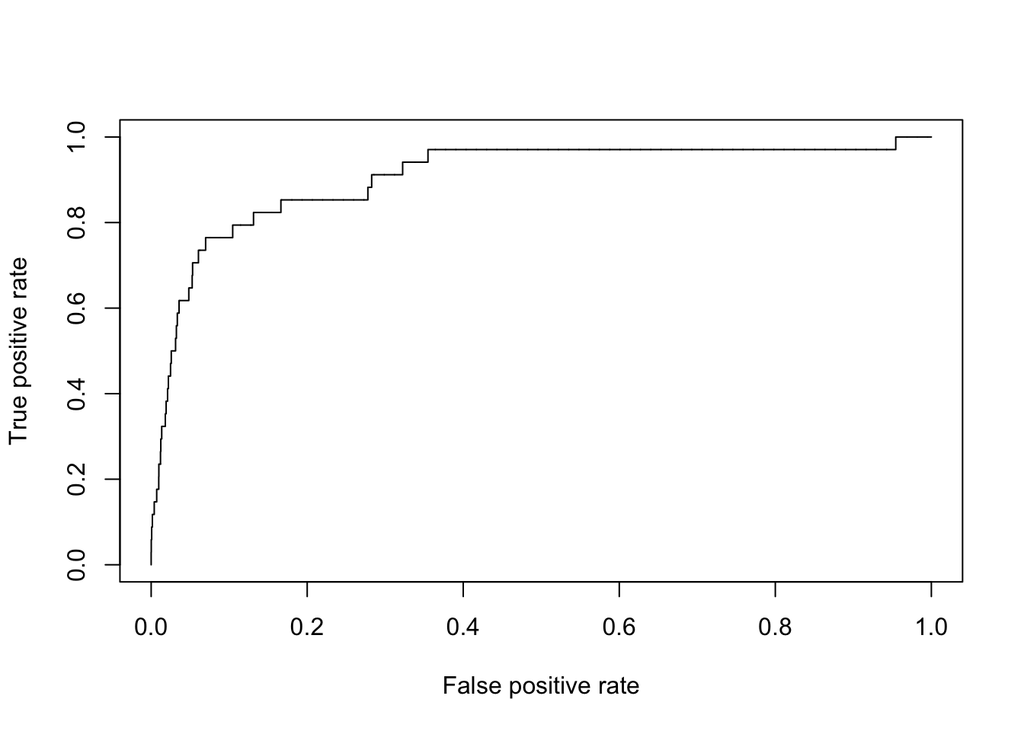

```r
pr <- prediction(final_rose$X1, truth)
prf <- performance(pr, measure = "tpr", x.measure = "fpr")
plot(prf)
```

```r
auc <- performance(pr, measure = "auc")
auc <- auc@y.values[[1]]
auc
```

```
## [1] 0.9054973
```

### Model building & Model evaluation - `rf`

```r
ctrl <- trainControl(method = "repeatedcv",
                     number = 10,
                     repeats = 3,
                     verboseIter = FALSE,
                     sampling = "rose")
set.seed(1)
model_rf_rose <- caret::train(y_buy ~ .,
                              data = training,
                              method = "rf",
                              importance = TRUE,
                              preProcess = c("scale", "center"),
                              trControl = ctrl)
final_rose2 <- data.frame(actual = truth, predict(model_rf_rose, newdata = testing, type = "prob"))
final_rose2$predict <- ifelse(final_rose2$X0 > 0.5, "0", "1")
confusionMatrix(final_rose2$predict, truth)
```

```
## Confusion Matrix and Statistics
##
##           Reference
## Prediction    0    1
##          0 7578   31
##          1   29    3
##
##                Accuracy : 0.9921
##                  95% CI : (0.9899, 0.994)
##     No Information Rate : 0.9956
##     P-Value [Acc > NIR] : 1.0000
##
##                   Kappa : 0.087
##  Mcnemar's Test P-Value : 0.8973
##
##             Sensitivity : 0.99619
##             Specificity : 0.08824
##          Pos Pred Value : 0.99593
##          Neg Pred Value : 0.09375
##              Prevalence : 0.99555
##          Detection Rate : 0.99176
##    Detection Prevalence : 0.99581
##       Balanced Accuracy : 0.54221
##
##        'Positive' Class : 0
##
```

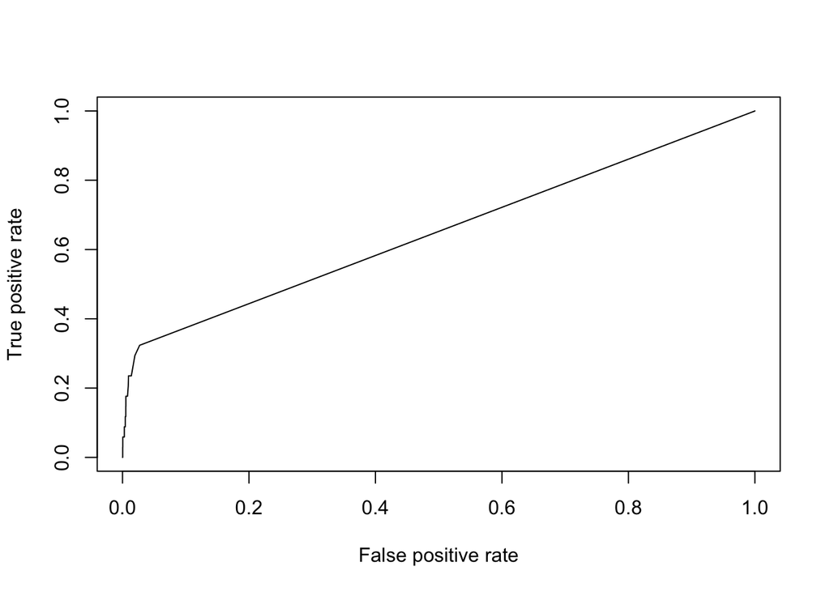

```r
pr2 <- prediction(final_rose2$X1, truth)
prf2 <- performance(pr2, measure = "tpr", x.measure = "fpr")
plot(prf2)
```

```r
auc2 <- performance(pr2, measure = "auc")
auc2 <- auc2@y.values[[1]]
auc2
```

```
## [1] 0.6498736
```

```r
varImp(model_rf_rose, scale = FALSE)
```

```
## rf variable importance
##
##                     Importance
## multiple_buy1           620.24
## expected_time_buy       424.34
## buy_interval            213.83
## isbuyer1                 88.68
## buy_freq                 87.70
## visit_freq               80.41
## multiple_visit1          36.28
## sv_interval              31.93
## last_buy                 28.99
## uniq_urls                20.50
## expected_time_visit      18.97
## num_checkins_log         11.54
```

### Model building & Model evaluation - `emsemble method`

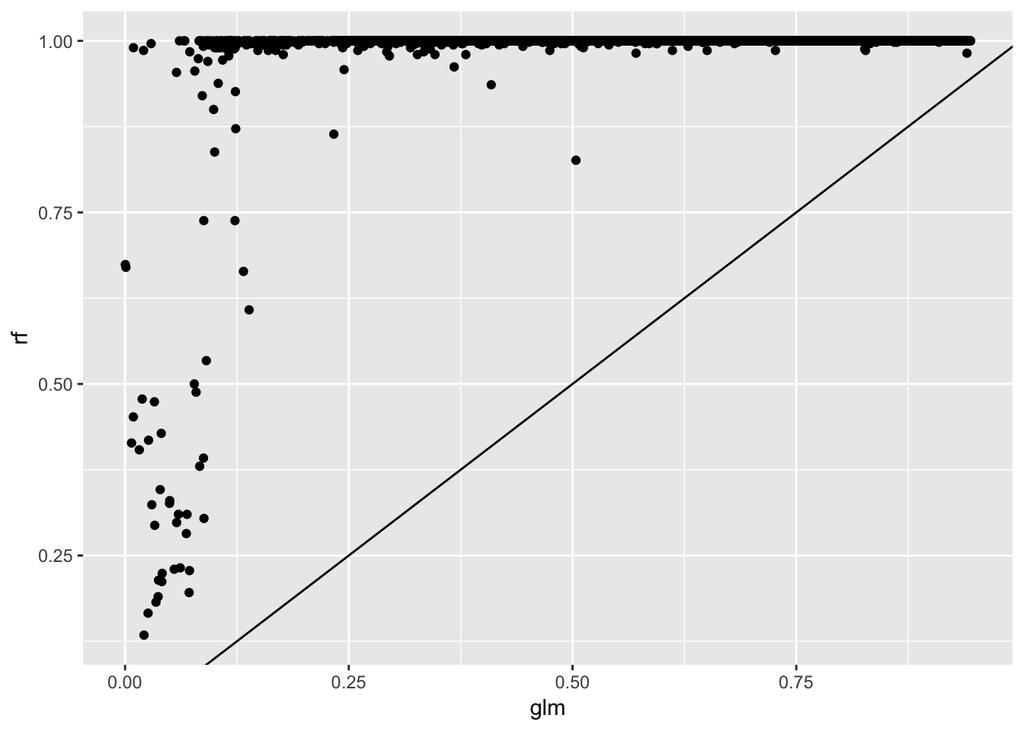

```r
preds <- cbind(final_rose$X0,final_rose2$X0) %>% as_tibble
colnames(preds) <- c('glm','rf')
preds %>% ggplot(aes(x=glm,y=rf)) + geom_point() + geom_abline(intercept = 0, slope=1)
```

```r
preds %<>% mutate(Avg=(glm+rf)/2)
preds$predict <- ifelse(preds$Avg > 0.5, "0", "1")
confusionMatrix(preds$predict, truth)
```

```
## Confusion Matrix and Statistics
##
##           Reference
## Prediction    0    1
##          0 7569   29
##          1   38    5
##
##                Accuracy : 0.9912
##                  95% CI : (0.9889, 0.9932)
##     No Information Rate : 0.9956
##     P-Value [Acc > NIR] : 1.0000
##
##                   Kappa : 0.1255
##  Mcnemar's Test P-Value : 0.3284
##
##             Sensitivity : 0.9950
##             Specificity : 0.1471
##          Pos Pred Value : 0.9962
##          Neg Pred Value : 0.1163
##              Prevalence : 0.9956
##          Detection Rate : 0.9906
##    Detection Prevalence : 0.9944
##       Balanced Accuracy : 0.5710
##
##        'Positive' Class : 0
##
```

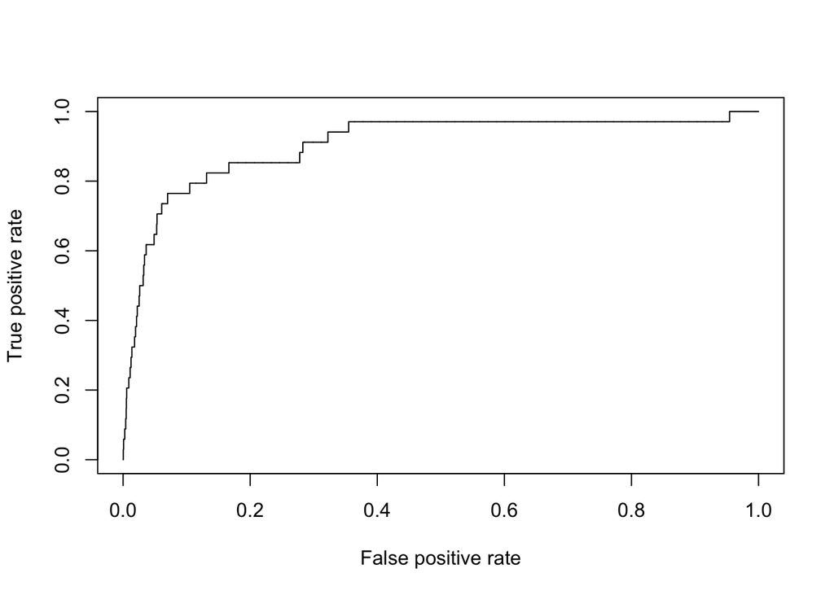

```r
pr3 <- prediction(1-preds$Avg, truth)
prf3 <- performance(pr3, measure = "tpr", x.measure = "fpr")
plot(prf3)
```

```r
auc3 <- performance(pr3, measure = "auc")
auc3 <- auc3@y.values[[1]]
auc3
```

```
## [1] 0.9053851
```

### Generate results

```r
ads_test$y_buy <- NULL
final0 <- data.frame(predict(model_glm_rose, newdata = ads_test, type = "prob"))
final1 <- data.frame(predict(model_rf_rose, newdata = ads_test, type = "prob"))
result <- cbind(final0$X0,final1$X0) %>% as_tibble
colnames(result) <- c('glm','rf')
result %<>% mutate(Avg=1-(glm+rf)/2)
result$predict <- ifelse(result$Avg > 0.5, "1", "0")
names(result)=c("final0","final1","Avg","predict")
result[,3:4] %>% write_csv('~/Downloads/result.csv')
```